# Project 01: The Science of Decisions: The Stroop Effect

## Question 1:

#### Independent Variable: Word Congruency, Dependent Variable: Recorded Time

The time it takes for subjects to name the ink colors in equally sized lists is what is being measured. This value **depends** on the type of list with which the subject is presented. The variable of word congruency (whether the color of ink matches the color described by the word) is what is being changed by the experimenter. Word congruency is the **independent** variable because it is the one whose effect is being measured.

## Question 2:

#### What is an appropriate set of hypotheses for this task? What kind of statistical test do you expect to perform? Justify your choices.

First of all, it seems important to note that this is a within subject, repeated measures design using paired dependent samples. The samples are dependent because the same subjects are tested for each of the tests.

**Set of Hypothoses**

- **H<sub>0</sub>: mu<sub>C</sub> >= mu<sub>I</sub>**
- **H<sub>1</sub>: mu<sub>C</sub> < mu<sub>I</sub>**

Where **mu<sub>C</sub>** is the population mean time for subjects to complete the congruent colors task, and **mu<sub>I</sub>** is the population mean time for subjects to complete the incongruent colors task. Essentially, the most basic null hypothesis would be that the observed difference in sample mean times for subjects completing the congruent color task versus the incongruent task is the result of chance and that both samples are drawn from a single distribution with one population mean. In this particular experiment however it seems more intuitive to hypothesize that the population mean time to complete an incongruent task is greater than the population mean time to complete the congruent one. That is, the alternative hypothesis is that these two popluations have different means and that the incongruent population has the greater of the two. This is a one-tailed test in the negative direction. Because this is a one-tailed test the formulation of the null hypothesis allows the mean of the congruent task population to be larger than or equal to the incongruent population. In short we are looking for evidence to reject the claim that the mean time of the congruent task population is greater than or equal to the mean time of the incongruent population.

## Question 3:

#### Report some descriptive statistics regarding this dataset. Include at least one measure of central tendency and at least one measure of variability.

```python
import pandas as pd
import numpy as np

path = r'~/Desktop/Udacity/DataScience/P1-Stroop/stroopdata.csv'
df = pd.read_csv(path)

labels = ['mean', 'median', 'variance', 'standard deviation']

congruent_results = [
    df['Congruent'].mean(), df['Congruent'].median(), df['Congruent'].var(), df['Congruent'].std()
]

incongruent_results = [
    df['Incongruent'].mean(), df['Incongruent'].median(), df['Incongruent'].var(), df['Incongruent'].std()
]

descriptive_statistics = pd.DataFrame({
        'measure' : pd.Series(labels),
        'Congruent' : pd.Series(congruent_results),
        'Incongruent' : pd.Series(incongruent_results)
    })

descriptive_statistics
```

|  | Congruent | Incongruent | measure |
| --- | --- | --- | --- |
| 0 | 14.051125 | 22.015917 | mean |
| 1 | 14.356500 | 21.017500 | median |
| 2 | 12.669029 | 23.011757 | variance |
| 3 | 3.559358 | 4.797057 | standard deviation |

## Question 4:

#### Provide one or two visualizations that show the distribution of the sample data. Write one or two sentences noting what you observe about the plot or plots.

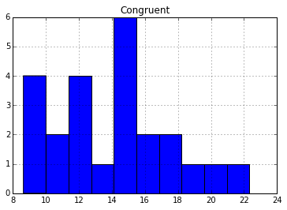

```python
%pylab inline

import matplotlib.pyplot as plt

congruent_times_histogram = pd.DataFrame.hist(df, column='Congruent')
```

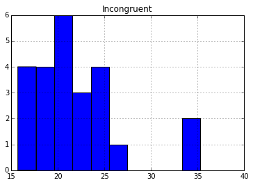

```python
incongruent_times_histogram = pd.DataFrame.hist(df, column='Incongruent')
```

After plotting the two histograms above, each with 10 bins, it seems as though there is a positive skew to the incongruent times, whereas the congruent times seem as though they are nearly normal in distribution.

## Question 5:

#### Now, perform the statistical test and report your results. What is your confidence level and your critical statistic value? Do you reject the null hypothesis or fail to reject it? Come to a conclusion in terms of the experiment task. Did the results match up with your expectations?

```python
df['Difference'] = df['Congruent'] - df['Incongruent']
df
```

|  | Congruent | Incongruent | Difference |
| --- | --- | --- | --- |
| 0 | 12.079 | 19.278 | -7.199 |
| 1 | 16.791 | 18.741 | -1.950 |
| 2 | 9.564 | 21.214 | -11.650 |
| 3 | 8.630 | 15.687 | -7.057 |
| 4 | 14.669 | 22.803 | -8.134 |
| 5 | 12.238 | 20.878 | -8.640 |
| 6 | 14.692 | 24.572 | -9.880 |
| 7 | 8.987 | 17.394 | -8.407 |
| 8 | 9.401 | 20.762 | -11.361 |
| 9 | 14.480 | 26.282 | -11.802 |
| 10 | 22.328 | 24.524 | -2.196 |
| 11 | 15.298 | 18.644 | -3.346 |
| 12 | 15.073 | 17.510 | -2.437 |
| 13 | 16.929 | 20.330 | -3.401 |
| 14 | 18.200 | 35.255 | -17.055 |
| 15 | 12.130 | 22.158 | -10.028 |
| 16 | 18.495 | 25.139 | -6.644 |
| 17 | 10.639 | 20.429 | -9.790 |
| 18 | 11.344 | 17.425 | -6.081 |
| 19 | 12.369 | 34.288 | -21.919 |
| 20 | 12.944 | 23.894 | -10.950 |
| 21 | 14.233 | 17.960 | -3.727 |
| 22 | 19.710 | 22.058 | -2.348 |
| 23 | 16.004 | 21.157 | -5.153 |

```python
# Compute the mean difference of the two samples: mu1 - mu2. This is the point estimate.
mean_difference = df['Congruent'].mean() - df['Incongruent'].mean()
print "The mean difference of the two samples is {0:.2f} seconds.  This means that on average subjects took {1:.2f} seconds longer to complete their incongruent list than to complete their congruent one.\n".format(mean_difference, abs(mean_difference))

# sanity check
assert(abs(mean_difference - df['Difference'].mean()) < 0.00001)

# Compute the sample standard deviation of the differences
sample_sigma = df.Difference.std()
print "The standard deviation of the difference of means between the two groups is {0:.2f} seconds.\n".format(sample_sigma)

# sanity check
assert(abs(sample_sigma - df['Difference'].std()) < 0.00001)

# Compute the standard error
standard_error = sample_sigma / sqrt(len(df.Difference))
print "The standard error is {0:.2f}".format(standard_error) ,

# Compute the t-statistic: mean difference / standard error
t_stat = mean_difference / standard_error
print "which means that the t-statistic is {0:.2f}.\n".format(t_stat)
```

```
The mean difference of the two samples is -7.96 seconds.  This means that on average subjects took 7.96 seconds longer to complete their incongruent list than to complete their congruent one.

The standard deviation of the difference of means between the two groups is 4.86 seconds.

The standard error is 0.99 which means that the t-statistic is -8.02.
```

#### Interpretation

Given that this is a one-tailed test in the negative direction, our t-critical value for a confidence level of alpha = 0.0005 with 23 degrees of freedom is -3.768. This means that there is less than a 0.05% chance (1/2000) of picking a samples from a single population whose means differed with a t-value of -3.768. In this case, the t-value is more than twice this critical value, meaning that it is practically an absolute certainty that these two samples come from different distributions.

To verify this result, let's look at the scipy.stats result.

```python
from scipy import stats

confirmation = stats.ttest_rel(df.Congruent, df.Incongruent)
confirmation
```

```
(-8.020706944109957, 4.1030005857111781e-08)
```

Bearing in mind that the second result is the p-value for a two-tailed test, we simply devid by two for to get our one-tailed value. Still, it is quite clear that it is extremely improbable that our result could be achieved by chance.

We can also compute the effect size using the measure of Cohen's d.

```python
# Compute Cohen's d
cohens_d = mean_difference / sample_sigma
print "Cohen's d is calculated to be {0:.2f} which indicates that the two means are {0:.2f} standard deviations apart.\n".format(cohens_d)

# Compute the Confidence Interval
confidence = 0.95
t_critical = 2.069
t_value = standard_error * t_critical
confidence_interval = (mean_difference - t_critical, mean_difference + t_critical)
print "Given that there is an effect on the mean that results from the treatment (applying incongruence), it is interesting to note the confidence interval of the effect. That is, within a given level of confidence, how much longer can we expect a subject to take to complete the incongruent naming task. In this case with a confidence interval of {0:.2f}% we can expect subjects to take between {1:.2f} and {2:.2f} seconds longer to complete the incongruent naming task than they would the congruent one.\n".format(confidence * 100, abs(confidence_interval[1]), abs(confidence_interval[0]))
```

[output not shown]

## Question 6:

#### Optional: What do you think is responsible for the effects observed? Can you think of an alternative or similar task that would result in a similar effect? Some research about the problem will be helpful for thinking about these two questions!

It seems quite likely that more work has to be done by subjects to filter the information based on the ink color rather than the word value. This makes sense if we accept the hypothesis that people learn to read by training pipeline pattern recognizers. That is, words are made up of letters, and letters are made up of lines and curves. Learning to read words is the result of learning to recognize a given collection of lines and curves as a given letter, and recognizing a given set of letters as that word. If the human brain uses shortcuts in this pipeline, it saves on the time needed to recognize any of the constituent sub patterns and can then quickly infer the larger pattern, in this case the word. These short cuts are a great help for the larger task of reading, but they are largely unconscious and are employed with a high degree of autonomy. That is, we do it without realizing that we are doing it. These sub tasks are invoked so often without our knowledge that ignoring their input becomes difficult. In effect, the subjects minds are shouting the color's name, the value of the word that is written, so loudly that it makes attending to the actual ink color more difficult.

It is difficult to think of a similar task that might might result in a similar given the fundamental nature of color and text. By this I mean if we wanted to do a similar study using facial recognition we wouldn't have an analog to color in which we could write the faces. Wikipedia does have list a few examples of similar experiments, but they don't seem to have the same degree of elegance.

# References

1. [The T-Table from Class](https://s3.amazonaws.com/udacity-hosted-downloads/t-table.jpg)
2. [Wikipedia](https://en.wikipedia.org/wiki/Stroop_effect#Warped_words)